# 4-17 Basics of R

Lei Gao

2020-11-29

# 4. Basics of R

# 4.3 Data Types

## 4.3.1 数值型

类型其他编程语言的`float`和`double`

```r
class(4L);class(2.8)
[1] "integer"
[1] "numeric"
```

## 4.3.2 Character Data

- character
- factor

```r
x <- "data"
y <- factor("data")
nchar(x)
[1] 4
#nchar(y)
nchar("hello")
[1] 5
```

## 4.3.3 Dates

```r
date1 <- as.Date("2020-11-19")
date1;class(date1)
[1] "2020-11-19"
[1] "Date"
```

```r
as.numeric(date1)
[1] 18585
```

```r
date2 <- as.POSIXct("2020-11-19 17:24")
date2;class(date2)
[1] "2020-11-19 17:24:00 EST"
[1] "POSIXct" "POSIXt"
```

专门针对Date数据的包，lubridate和chron等。

## 4.3.4 Logical

```r
TRUE*5;FALSE*5
[1] 5
[1] 0
```

# 4.4 Vectors

vectors don’t have dimension, meaning there is no such thing as a column vector or row vector.

## 4.4.1 向量操作

```r
x <- c(1:10)
x*3;x+2;x-2;x/4;x^2;sqrt(x)
 [1]  3  6  9 12 15 18 21 24 27 30
 [1]  3  4  5  6  7  8  9 10 11 12
 [1] -1  0  1  2  3  4  5  6  7  8
 [1] 0.25 0.50 0.75 1.00 1.25 1.50 1.75 2.00 2.25 2.50
 [1]   1   4   9  16  25  36  49  64  81 100
 [1] 1.000000 1.414214 1.732051 2.000000 2.236068 2.449490 2.645751 2.828427
 [9] 3.000000 3.162278
```

检查所有的元素是否符合要求：all()

检查任意元素是否符合要求：any()

```r
x <- 10:1
y <-  -4:5
any(x<5);all(x<y)
[1] TRUE
[1] FALSE
```

## 4.4.2 factor vectors

```r
q <- c("Hockey", "Football", "Baseball", "Curling", "Rugby",
       "Lacrosse", "Basketball", "Tennis", "Cricket", "Soccer")
q2 <- c(q, "Hockey", "Lacrosse", "Hockey", "Water Polo","Hockey", "Lacrosse")
q2Factor <- as.factor(q2)
q2Factor
 [1] Hockey     Football   Baseball   Curling    Rugby      Lacrosse
 [7] Basketball Tennis     Cricket    Soccer     Hockey     Lacrosse
[13] Hockey     Water Polo Hockey     Lacrosse
11 Levels: Baseball Basketball Cricket Curling Football Hockey ... Water Polo
```

```r
as.numeric(q2Factor)
 [1]  6  5  1  4  8  7  2 10  3  9  6  7  6 11  6  7
```

```r
factor(x=c("High School", "College", "Masters", "Doctorate"),
  levels=c("High School", "College", "Masters", "Doctorate"),
 ordered=TRUE) #有序因子变量
[1] High School College     Masters     Doctorate
Levels: High School < College < Masters < Doctorate
```

# 4.6 Function Documentation

apropos来自Latin propositium，含义是：purpose，plan.

```r
apropos("mea") #Find Objects By (Partial) Name
 [1] ".colMeans"          ".rowMeans"          "colMeans"
 [4] "cummean"            "influence.measures" "kmeans"
 [7] "mean"               "mean.Date"          "mean.default"
[10] "mean.difftime"      "mean.POSIXct"       "mean.POSIXlt"
[13] "mean_cl_boot"       "mean_cl_normal"     "mean_sdl"
[16] "mean_se"            "rowMeans"           "weighted.mean"
```

# 5. Advanced Data Structures

# 5.1 数据框

- names(), rownames()
- head(),tail()
- nrow(),ncol(),dim()
- class()

为了保证输出的结果是single-column data.frame, 可在提取数据时，加入参数：drop=FALSE,保证提取的元素组成的仍是数据框。

```r
x <- 10:1
y <-  -4:5
q <- c("Hockey", "Football", "Baseball", "Curling", "Rugby",
       "Lacrosse", "Basketball", "Tennis", "Cricket", "Soccer")
theDF <- data.frame(x,y,q)
class(theDF[,"q"]);class(theDF[,1]);class(theDF["q"]);class(theDF[,"q",drop=FALSE])
[1] "character"
[1] "integer"
[1] "data.frame"
[1] "data.frame"
```

## 5.2 Lists

像data.frames一样，lists也是有names的。

```r
list5 <- list(theDF,1:10)
names(list5);names(list5) <- c("data.frame","vector")
NULL
```

取list中的单个元素时，用[[]]（双括号）

```r
list5[[1]]
    x  y          q
1  10 -4     Hockey
2   9 -3   Football
3   8 -2   Baseball
4   7 -1    Curling
5   6  0      Rugby
6   5  1   Lacrosse
7   4  2 Basketball
8   3  3     Tennis
9   2  4    Cricket
10  1  5     Soccer
```

查看list的维度：length(list)

```r
length(list5)
[1] 2
```

# 6. Reading Data into R

推荐函数：

- read.table()
- readr::read_delim()
- data.table::fread()

## 6.2 Excel 数据

readxl→轻松读取*.xls和*.xlsx文件

readxl::read_excel(file,sheet=" ")→读取excel文件，并选取要读取的sheet

# 7.统计绘图

## 7.1 基础绘图

```r
rm(list = ls())
library(ggplot2)
data("diamonds")
head(diamonds,n=3)
# A tibble: 3 x 10
  carat cut     color clarity depth table price     x     y     z
  <dbl> <ord>   <ord> <ord>   <dbl> <dbl> <int> <dbl> <dbl> <dbl>
1  0.23 Ideal   E     SI2      61.5    55   326  3.95  3.98  2.43
2  0.21 Premium E     SI1      59.8    61   326  3.89  3.84  2.31
3  0.23 Good    E     VS1      56.9    65   327  4.05  4.07  2.31
```

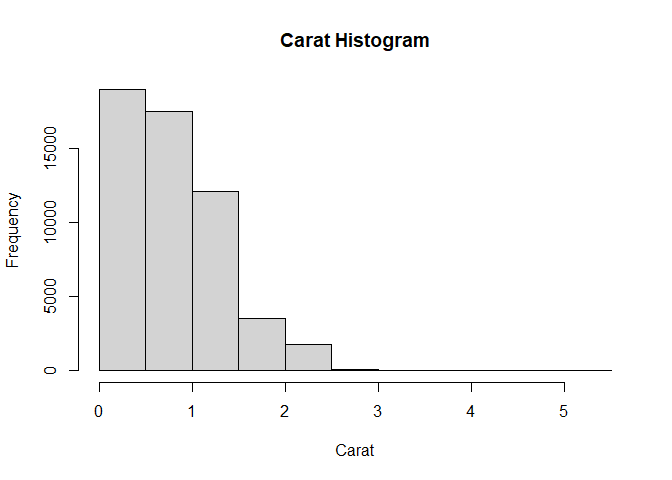

```r
hist(diamonds$carat,main = "Carat Histogram",xlab = "Carat")
```

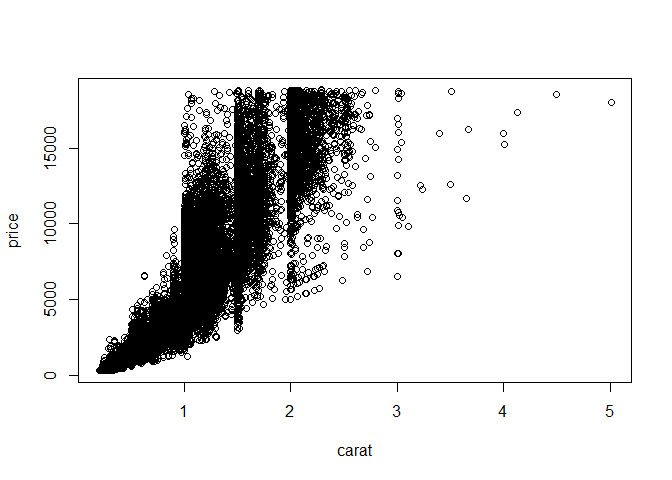

```r
plot(price~carat,data = diamonds) #y~x格式
```

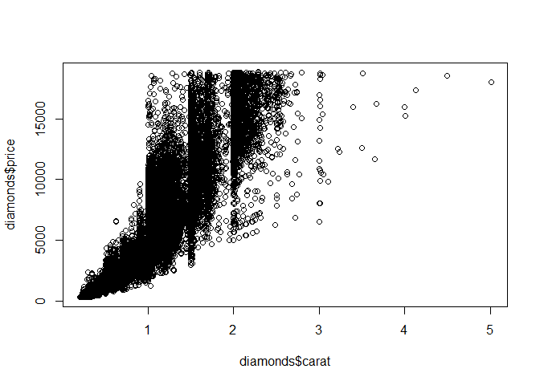

```r
plot(diamonds$carat,diamonds$price)
```

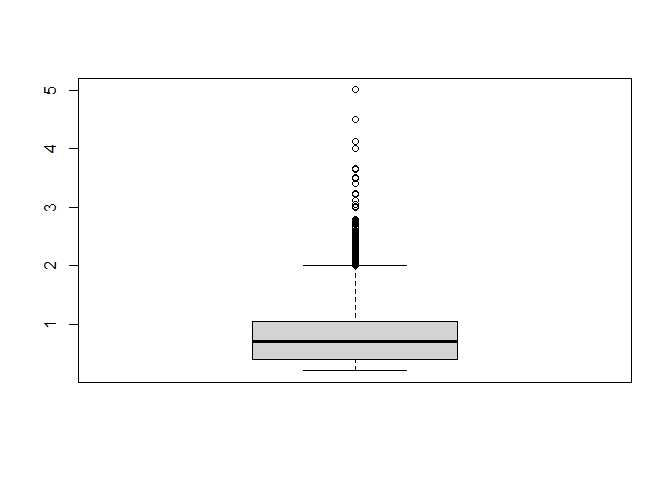

```r
boxplot(diamonds$carat)
```

## 7.2 ggplot2

geome_line()设置参数，aes(group=1)

# 8.Writing R functions

## 8.1 Hello, World!

```r
say.hello <- function(){
  print("Hello, World!")
}
say.hello
function(){
  print("Hello, World!")
}
```

## 8.2 Function arguments

sprintf():进行字符串的迭代，全称string print function, 来自于C语言。

```r
#单个迭代
sprintf("Hello %s!","Richard")
[1] "Hello Richard!"
```

```r
#多个迭代
sprintf("Hello %s, today is %s!","Richard","Saturday")
[1] "Hello Richard, today is Saturday!"
```

```r
#建立函数
hello.person <- function(name){
  sprintf("Hello %s!",name)
}
hello.person("Richard")
[1] "Hello Richard!"
```

```r
#多个参数
hello.person <- function(first,second){
  sprintf("Hello %s and %s!",first,second)
}
hello.person("Richard","Brain")
[1] "Hello Richard and Brain!"
```

### 8.2.1 Default argument (缺省值)

```r
hello.person <- function(first,last="Dove"){
  sprintf("Hello %s and %s",first,last)
}
hello.person("Richard");hello.person("Richard","Brain")
[1] "Hello Richard and Dove"
[1] "Hello Richard and Brain"
```

### 8.2.2 Extra argument

```r
hello.person <- function(first,last="Dove",...){
  sprintf("Hello %s and %s",first,last)
}
hello.person("Richard",extra="Goodbye")
[1] "Hello Richard and Dove"
```

## 8.3 Return values

```r
# 隐式返回
double.number <- function(x){
  x^2
}
double.number(10)
[1] 100
```

```r
# 显式返回
double.number <- function(x){
  return(x^2)
}
double.number(10)
[1] 100
```

## 8.4 do.call

```r
run.this <- function(x,func=mean){
  do.call(func,args = list(x))
}
run.this(1:10)
[1] 5.5
```

```r
#修改默认参数
run.this(1:10,sd)
[1] 3.02765
```

# 9.控制语句

## 9.1 if&else

- if: If something is TURE, then perform some action; otherwise, don not perform that action.

```r
toCheck=1
check.box <- function(toCheck){
  if(toCheck==1){
    print("Hello!")
  }else{
    print("Goodbye!")
  }
}

check.box(0);check.box(TRUE)
[1] "Goodbye!"
[1] "Hello!"
```

```r
#else if
check.bool <- function(x){
  if(x==0){
    print("Hello!")
  }else if (x==1){
    print("Goodbye!")
  } else{
    print("Confused!")
  }
}
check.bool(3)
[1] "Confused!"
```

## 9.2 switch

```r
use.switch <- function(x){
  switch(x,
    "a"="first",
    "b"="second",
    "c"="third",
    "d"="fourth",
    "other"
  )
}
use.switch("a")
[1] "first"
```

## 9.3 ifelse

```r
ifelse(1==0,"Yes","NO")
[1] "NO"
```

```r
totest <- c(1,2,3,1,2)
ifelse(totest==1,"Yes","NO")
[1] "Yes" "NO"  "NO"  "Yes" "NO"
```

```r
ifelse(totest==1,totest*3,totest)
[1] 3 2 3 3 2
```

## 9.4 Compound Tests

- && 和|| 用于if，仅test第一个
- & 和 | 检测所有

```r
a <- c(1,1,0,1)
b <- c(2,1,0,1)
ifelse(a==1&b==1,"Yes","No");ifelse(a==1&&b==1,"Yes","No")
[1] "No"  "Yes" "No"  "Yes"
[1] "No"
```

# 10. loop(循环)

## 10.1 for

```r
fruit <- c("apple", "banana", "pomegranate")
fruitLength <- rep(NA,length(fruit))
names(fruitLength) <- fruit
for (a in fruit){
  fruitLength[a]=nchar(a)
}
fruitLength
      apple      banana pomegranate
          5           6          11
```

## 10.2 while

```r
x=1
while(x<=5){
  print(x)
  x=x+1
}
[1] 1
[1] 2
[1] 3
[1] 4
[1] 5
```

## 10.3 next&break

```r
# next
for (i in 1:10){
  if (i==3)
  {next}
  print(i)
  }
[1] 1
[1] 2
[1] 4
[1] 5
[1] 6
[1] 7
[1] 8
[1] 9
[1] 10
```

```r
#break
for (i in 1:10){
  if(i==4){
    break
  }
  print(i)
}
[1] 1
[1] 2
[1] 3
```

Notes: As stated earlier, if a solution can be done without loops, via vectorization or matrix algebra, then avoid the loop. It is particularly important to avoid nested loops. Loops inside other loops are extremely slow in R.

# 11.Group manipulation

在数据分析中，manipulating the data占据80%的时间。整个过程：split-apply-combine

## 11.1 apply家族

### 11.1.1 apply

```r
theMatrix <- matrix(1:9,nrow = 3)
theMatrix
     [,1] [,2] [,3]
[1,]    1    4    7
[2,]    2    5    8
[3,]    3    6    9
```

```r
# sum the rows
apply(theMatrix,1,sum)
[1] 12 15 18
```

```r
# sum the columns
apply(theMatrix, 2, sum)
[1]  6 15 24
```

当然在baseR中有rowSums和colSums与之对应。

```r
rowSums(theMatrix);colSums(theMatrix)
[1] 12 15 18
[1]  6 15 24
```

当有NA存在时，the result of sum will be NA.

```r
theMatrix[2,1] <- NA
apply(theMatrix, 1, sum)
[1] 12 NA 18
```

```r
#na.rm=TRUE 去除NA
apply(theMatrix,1,sum,na.rm=T)
[1] 12 13 18
```

### 11.1.2 lapply和mapply

```r
# lapply对list中的每一个元素应用function
theList <- list(A=matrix(1:9,3),B=1:5,C=matrix(1:4,2),D=2)
lapply(theList, sum)
$A
[1] 45

$B
[1] 15

$C
[1] 10

$D
[1] 2
```

```r
# sapply:对list的每一个元素应用后，返回结果为vector.
sapply(theList, sum)
 A  B  C  D
45 15 10  2
```

```r
theNames <- c("Jared","Deb","Paul")
lapply(theNames, nchar)
[[1]]
[1] 5

[[2]]
[1] 3

[[3]]
[1] 4
```

### 11.1.3 mapply

```r
#随机生存两个list
firstList <- list(A=matrix(1:16,4),B=matrix(1:16,2),C=1:5)
secondList <- list(A=matrix(1:16,4),B=matrix(1:16,8),C=15:1)
mapply(identical,firstList,secondList) #判断连个list的每个元素是否相同
    A     B     C
 TRUE FALSE FALSE
```

```r
# build simply function
simpleFunc <- function(x,y){
  NROW(x)+NROW(y)
}
mapply(simpleFunc, firstList,secondList)
 A  B  C
 8 10 20
```

## 11.2 aggregate

```r
data("diamonds")
head(diamonds,3)
# A tibble: 3 x 10
  carat cut     color clarity depth table price     x     y     z
  <dbl> <ord>   <ord> <ord>   <dbl> <dbl> <int> <dbl> <dbl> <dbl>
1  0.23 Ideal   E     SI2      61.5    55   326  3.95  3.98  2.43
2  0.21 Premium E     SI1      59.8    61   326  3.89  3.84  2.31
3  0.23 Good    E     VS1      56.9    65   327  4.05  4.07  2.31
```

```r
aggregate(price~cut,diamonds,mean) #按照cut计算price的平均值
        cut    price
1      Fair 4358.758
2      Good 3928.864
3 Very Good 3981.760
4   Premium 4584.258
5     Ideal 3457.542
```

```r
aggregate(price~cut+color,diamonds,mean) #按照cut,color计算price的平均值
         cut color    price
1       Fair     D 4291.061
2       Good     D 3405.382
3  Very Good     D 3470.467
4    Premium     D 3631.293
5      Ideal     D 2629.095
6       Fair     E 3682.312
7       Good     E 3423.644
8  Very Good     E 3214.652
9    Premium     E 3538.914
10     Ideal     E 2597.550
11      Fair     F 3827.003
12      Good     F 3495.750
13 Very Good     F 3778.820
14   Premium     F 4324.890
15     Ideal     F 3374.939
16      Fair     G 4239.255
17      Good     G 4123.482
18 Very Good     G 3872.754
19   Premium     G 4500.742
20     Ideal     G 3720.706
21      Fair     H 5135.683
22      Good     H 4276.255
23 Very Good     H 4535.390
24   Premium     H 5216.707
25     Ideal     H 3889.335
26      Fair     I 4685.446
27      Good     I 5078.533
28 Very Good     I 5255.880
29   Premium     I 5946.181
30     Ideal     I 4451.970
31      Fair     J 4975.655
32      Good     J 4574.173
33 Very Good     J 5103.513
34   Premium     J 6294.592
35     Ideal     J 4918.186
```

```r
aggregate(cbind(price,carat)~cut,diamonds,mean) # 双y值
        cut    price     carat
1      Fair 4358.758 1.0461366
2      Good 3928.864 0.8491847
3 Very Good 3981.760 0.8063814
4   Premium 4584.258 0.8919549
5     Ideal 3457.542 0.7028370
```

```r
aggregate(cbind(price,carat)~cut+color,diamonds,mean) #双y值，x值
         cut color    price     carat
1       Fair     D 4291.061 0.9201227
2       Good     D 3405.382 0.7445166
3  Very Good     D 3470.467 0.6964243
4    Premium     D 3631.293 0.7215471
5      Ideal     D 2629.095 0.5657657
6       Fair     E 3682.312 0.8566071
7       Good     E 3423.644 0.7451340
8  Very Good     E 3214.652 0.6763167
9    Premium     E 3538.914 0.7177450
10     Ideal     E 2597.550 0.5784012
11      Fair     F 3827.003 0.9047115
12      Good     F 3495.750 0.7759296
13 Very Good     F 3778.820 0.7409612
14   Premium     F 4324.890 0.8270356
15     Ideal     F 3374.939 0.6558285
16      Fair     G 4239.255 1.0238217
17      Good     G 4123.482 0.8508955
18 Very Good     G 3872.754 0.7667986
19   Premium     G 4500.742 0.8414877
20     Ideal     G 3720.706 0.7007146
21      Fair     H 5135.683 1.2191749
22      Good     H 4276.255 0.9147293
23 Very Good     H 4535.390 0.9159485
24   Premium     H 5216.707 1.0164492
25     Ideal     H 3889.335 0.7995249
26      Fair     I 4685.446 1.1980571
27      Good     I 5078.533 1.0572222
28 Very Good     I 5255.880 1.0469518
29   Premium     I 5946.181 1.1449370
30     Ideal     I 4451.970 0.9130291
31      Fair     J 4975.655 1.3411765
32      Good     J 4574.173 1.0995440
33 Very Good     J 5103.513 1.1332153
34   Premium     J 6294.592 1.2930941
35     Ideal     J 4918.186 1.0635937
```

```r
# 同时计算mean和median
library(plyr)
aggregate(price~cut,diamonds,each(mean,median))
        cut price.mean price.median
1      Fair   4358.758     3282.000
2      Good   3928.864     3050.500
3 Very Good   3981.760     2648.000
4   Premium   4584.258     3185.000
5     Ideal   3457.542     1810.000
```

## 11.4 data.table

```r
library(data.table)
theDF <- data.frame(A=1:10,
                    B=letters[1:10],
                    C=LETTERS[11:20],
                    D=rep(c("One", "Two", "Three"), length.out=10))
theDT <- data.table(A=1:10,
                    B=letters[1:10],
                    C=LETTERS[11:20],
                    D=rep(c("One", "Two", "Three"), length.out=10))
theDF;theDT
    A B C     D
1   1 a K   One
2   2 b L   Two
3   3 c M Three
4   4 d N   One
5   5 e O   Two
6   6 f P Three
7   7 g Q   One
8   8 h R   Two
9   9 i S Three
10 10 j T   One
     A B C     D
 1:  1 a K   One
 2:  2 b L   Two
 3:  3 c M Three
 4:  4 d N   One
 5:  5 e O   Two
 6:  6 f P Three
 7:  7 g Q   One
 8:  8 h R   Two
 9:  9 i S Three
10: 10 j T   One
```

```r
class(theDF$B);class(theDT$B)
[1] "character"
[1] "character"
```

```r
diamondsDT <- data.table(diamonds)
diamondsDT
       carat       cut color clarity depth table price    x    y    z
    1:  0.23     Ideal     E     SI2  61.5    55   326 3.95 3.98 2.43
    2:  0.21   Premium     E     SI1  59.8    61   326 3.89 3.84 2.31
    3:  0.23      Good     E     VS1  56.9    65   327 4.05 4.07 2.31
    4:  0.29   Premium     I     VS2  62.4    58   334 4.20 4.23 2.63
    5:  0.31      Good     J     SI2  63.3    58   335 4.34 4.35 2.75
   ---
53936:  0.72     Ideal     D     SI1  60.8    57  2757 5.75 5.76 3.50
53937:  0.72      Good     D     SI1  63.1    55  2757 5.69 5.75 3.61
53938:  0.70 Very Good     D     SI1  62.8    60  2757 5.66 5.68 3.56
53939:  0.86   Premium     H     SI2  61.0    58  2757 6.15 6.12 3.74
53940:  0.75     Ideal     D     SI2  62.2    55  2757 5.83 5.87 3.64
```

```r
theDT[,"B",with=FALSE];theDT[,c("A","C"),with=FALSE]
    B
 1: a
 2: b
 3: c
 4: d
 5: e
 6: f
 7: g
 8: h
 9: i
10: j
     A C
 1:  1 K
 2:  2 L
 3:  3 M
 4:  4 N
 5:  5 O
 6:  6 P
 7:  7 Q
 8:  8 R
 9:  9 S
10: 10 T
```

### 11.4.1 Keys键值

Keys键值，就是行名

```r
tables() #show tables
         NAME   NROW NCOL MB                                    COLS KEY
1: diamondsDT 53,940   10  3 carat,cut,color,clarity,depth,table,...
2:      theDT     10    4  0                                 A,B,C,D
Total: 3MB
```

```r
setkey(theDT,D)
theDT
     A B C     D
 1:  1 a K   One
 2:  4 d N   One
 3:  7 g Q   One
 4: 10 j T   One
 5:  3 c M Three
 6:  6 f P Three
 7:  9 i S Three
 8:  2 b L   Two
 9:  5 e O   Two
10:  8 h R   Two
```

```r
key(theDT);tables()
[1] "D"
         NAME   NROW NCOL MB                                    COLS KEY
1: diamondsDT 53,940   10  3 carat,cut,color,clarity,depth,table,...
2:      theDT     10    4  0                                 A,B,C,D   D
Total: 3MB
```

根据Keys键值选取数据

```r
theDT["One",]
    A B C   D
1:  1 a K One
2:  4 d N One
3:  7 g Q One
4: 10 j T One
```

```r
# 多个columns可被设置为key
setkey(diamondsDT,cut,color)
```

```r
# 一次性取多个行
diamondsDT[J("Ideal","E"),]
      carat   cut color clarity depth table price    x    y    z
   1:  0.23 Ideal     E     SI2  61.5    55   326 3.95 3.98 2.43
   2:  0.26 Ideal     E    VVS2  62.9    58   554 4.02 4.06 2.54
   3:  0.70 Ideal     E     SI1  62.5    57  2757 5.70 5.72 3.57
   4:  0.59 Ideal     E    VVS2  62.0    55  2761 5.38 5.43 3.35
   5:  0.74 Ideal     E     SI2  62.2    56  2761 5.80 5.84 3.62
  ---
3899:  0.70 Ideal     E     SI1  61.7    55  2745 5.71 5.74 3.53
3900:  0.51 Ideal     E    VVS1  61.9    54  2745 5.17 5.11 3.18
3901:  0.56 Ideal     E    VVS1  62.1    56  2750 5.28 5.29 3.28
3902:  0.77 Ideal     E     SI2  62.1    56  2753 5.84 5.86 3.63
3903:  0.71 Ideal     E     SI1  61.9    56  2756 5.71 5.73 3.54
```

```r
diamondsDT[J("Ideal",c("E","D")),]
      carat   cut color clarity depth table price    x    y    z
   1:  0.23 Ideal     E     SI2  61.5    55   326 3.95 3.98 2.43
   2:  0.26 Ideal     E    VVS2  62.9    58   554 4.02 4.06 2.54
   3:  0.70 Ideal     E     SI1  62.5    57  2757 5.70 5.72 3.57
   4:  0.59 Ideal     E    VVS2  62.0    55  2761 5.38 5.43 3.35
   5:  0.74 Ideal     E     SI2  62.2    56  2761 5.80 5.84 3.62
  ---
6733:  0.51 Ideal     D    VVS2  61.7    56  2742 5.16 5.14 3.18
6734:  0.51 Ideal     D    VVS2  61.3    57  2742 5.17 5.14 3.16
6735:  0.81 Ideal     D     SI1  61.5    57  2748 6.00 6.03 3.70
6736:  0.72 Ideal     D     SI1  60.8    57  2757 5.75 5.76 3.50
6737:  0.75 Ideal     D     SI2  62.2    55  2757 5.83 5.87 3.64
```

### 11.4.2 data.table aggregation

```r
aggregate(price~cut,diamonds,mean)
        cut    price
1      Fair 4358.758
2      Good 3928.864
3 Very Good 3981.760
4   Premium 4584.258
5     Ideal 3457.542
```

```r
# 在data.table可得到相同的结果

diamondsDT[,mean(price),by=cut]
         cut       V1
1:      Fair 4358.758
2:      Good 3928.864
3: Very Good 3981.760
4:   Premium 4584.258
5:     Ideal 3457.542
```

```r
# aggregate 和 data.table唯一不同的是名称不同

diamondsDT[,list(price=mean(price)),by=cut]
         cut    price
1:      Fair 4358.758
2:      Good 3928.864
3: Very Good 3981.760
4:   Premium 4584.258
5:     Ideal 3457.542
```

```r
# 多个分组变量时，用list()
diamondsDT[,mean(price),by=list(cut,color)]
          cut color       V1
 1:      Fair     D 4291.061
 2:      Fair     E 3682.312
 3:      Fair     F 3827.003
 4:      Fair     G 4239.255
 5:      Fair     H 5135.683
 6:      Fair     I 4685.446
 7:      Fair     J 4975.655
 8:      Good     D 3405.382
 9:      Good     E 3423.644
10:      Good     F 3495.750
11:      Good     G 4123.482
12:      Good     H 4276.255
13:      Good     I 5078.533
14:      Good     J 4574.173
15: Very Good     D 3470.467
16: Very Good     E 3214.652
17: Very Good     F 3778.820
18: Very Good     G 3872.754
19: Very Good     H 4535.390
20: Very Good     I 5255.880
21: Very Good     J 5103.513
22:   Premium     D 3631.293
23:   Premium     E 3538.914
24:   Premium     F 4324.890
25:   Premium     G 4500.742
26:   Premium     H 5216.707
27:   Premium     I 5946.181
28:   Premium     J 6294.592
29:     Ideal     D 2629.095
30:     Ideal     E 2597.550
31:     Ideal     F 3374.939
32:     Ideal     G 3720.706
33:     Ideal     H 3889.335
34:     Ideal     I 4451.970
35:     Ideal     J 4918.186
          cut color       V1
```

```r
diamondsDT[,list(price=mean(price),carat=mean(carat)),by=cut]
         cut    price     carat
1:      Fair 4358.758 1.0461366
2:      Good 3928.864 0.8491847
3: Very Good 3981.760 0.8063814
4:   Premium 4584.258 0.8919549
5:     Ideal 3457.542 0.7028370
```

# 12. dplyr

Hadley Wickham 基于plyr包，开发了一系列的R包，其中dplyr主要针对data.frames, 而purrr主要针对list和vector，相比之下plyr有逐渐被替代的趋势。

## 12.1 Pipes 管道符

```r
library(magrittr)
data(diamonds)
dim(head(diamonds,n=4))
[1]  4 10
```

```r
diamonds %>%
  head(4) %>%
  dim
[1]  4 10
```

## 12.2 tbl

```r
class(diamonds);head(diamonds)
[1] "tbl_df"     "tbl"        "data.frame"
# A tibble: 6 x 10
  carat cut       color clarity depth table price     x     y     z
  <dbl> <ord>     <ord> <ord>   <dbl> <dbl> <int> <dbl> <dbl> <dbl>
1 0.23  Ideal     E     SI2      61.5    55   326  3.95  3.98  2.43
2 0.21  Premium   E     SI1      59.8    61   326  3.89  3.84  2.31
3 0.23  Good      E     VS1      56.9    65   327  4.05  4.07  2.31
4 0.290 Premium   I     VS2      62.4    58   334  4.2   4.23  2.63
5 0.31  Good      J     SI2      63.3    58   335  4.34  4.35  2.75
6 0.24  Very Good J     VVS2     62.8    57   336  3.94  3.96  2.48
```

## 12.3 select

```r
# 选择列
select(diamonds,carat,price)
# A tibble: 53,940 x 2
   carat price
   <dbl> <int>
 1 0.23    326
 2 0.21    326
 3 0.23    327
 4 0.290   334
 5 0.31    335
 6 0.24    336
 7 0.24    336
 8 0.26    337
 9 0.22    337
10 0.23    338
# ... with 53,930 more rows
```

```r
# 等价于
diamonds %>%
  select(carat,price)
# A tibble: 53,940 x 2
   carat price
   <dbl> <int>
 1 0.23    326
 2 0.21    326
 3 0.23    327
 4 0.290   334
 5 0.31    335
 6 0.24    336
 7 0.24    336
 8 0.26    337
 9 0.22    337
10 0.23    338
# ... with 53,930 more rows
```

```r
# one_of()

diamonds %>%
  select(one_of("carat","price"))
# A tibble: 53,940 x 2
   carat price
   <dbl> <int>
 1 0.23    326
 2 0.21    326
 3 0.23    327
 4 0.290   334
 5 0.31    335
 6 0.24    336
 7 0.24    336
 8 0.26    337
 9 0.22    337
10 0.23    338
# ... with 53,930 more rows
```

```r
diamonds[,c('carat','price')] #传统方法提取列
# A tibble: 53,940 x 2
   carat price
   <dbl> <int>
 1 0.23    326
 2 0.21    326
 3 0.23    327
 4 0.290   334
 5 0.31    335
 6 0.24    336
 7 0.24    336
 8 0.26    337
 9 0.22    337
10 0.23    338
# ... with 53,930 more rows
```

```r
# starts_with,ends_with,contains
diamonds %>%
  select(starts_with("c")) #提取以“c”开头的列
# A tibble: 53,940 x 4
   carat cut       color clarity
   <dbl> <ord>     <ord> <ord>
 1 0.23  Ideal     E     SI2
 2 0.21  Premium   E     SI1
 3 0.23  Good      E     VS1
 4 0.290 Premium   I     VS2
 5 0.31  Good      J     SI2
 6 0.24  Very Good J     VVS2
 7 0.24  Very Good I     VVS1
 8 0.26  Very Good H     SI1
 9 0.22  Fair      E     VS2
10 0.23  Very Good H     VS1
# ... with 53,930 more rows
```

```r
diamonds %>%
  select(ends_with("e")) #提取以“e”结尾的列
# A tibble: 53,940 x 2
   table price
   <dbl> <int>
 1    55   326
 2    61   326
 3    65   327
 4    58   334
 5    58   335
 6    57   336
 7    57   336
 8    55   337
 9    61   337
10    61   338
# ... with 53,930 more rows
```

```r
diamonds %>%
  select(contains("l")) #提取包含l的列
# A tibble: 53,940 x 3
   color clarity table
   <ord> <ord>   <dbl>
 1 E     SI2        55
 2 E     SI1        61
 3 E     VS1        65
 4 I     VS2        58
 5 J     SI2        58
 6 J     VVS2       57
 7 I     VVS1       57
 8 H     SI1        55
 9 E     VS2        61
10 H     VS1        61
# ... with 53,930 more rows
```

```r
#  matches 正则表达式
diamonds %>%
  select(matches('r.+t')) # 与r.+t匹配的列
# A tibble: 53,940 x 2
   carat clarity
   <dbl> <ord>
 1 0.23  SI2
 2 0.21  SI1
 3 0.23  VS1
 4 0.290 VS2
 5 0.31  SI2
 6 0.24  VVS2
 7 0.24  VVS1
 8 0.26  SI1
 9 0.22  VS2
10 0.23  VS1
# ... with 53,930 more rows
```

```r
# by name

diamonds %>%
  select(-carat, -price) #去除carat和price
# A tibble: 53,940 x 8
   cut       color clarity depth table     x     y     z
   <ord>     <ord> <ord>   <dbl> <dbl> <dbl> <dbl> <dbl>
 1 Ideal     E     SI2      61.5    55  3.95  3.98  2.43
 2 Premium   E     SI1      59.8    61  3.89  3.84  2.31
 3 Good      E     VS1      56.9    65  4.05  4.07  2.31
 4 Premium   I     VS2      62.4    58  4.2   4.23  2.63
 5 Good      J     SI2      63.3    58  4.34  4.35  2.75
 6 Very Good J     VVS2     62.8    57  3.94  3.96  2.48
 7 Very Good I     VVS1     62.3    57  3.95  3.98  2.47
 8 Very Good H     SI1      61.9    55  4.07  4.11  2.53
 9 Fair      E     VS2      65.1    61  3.87  3.78  2.49
10 Very Good H     VS1      59.4    61  4     4.05  2.39
# ... with 53,930 more rows
```

```r
# 等价于
diamonds %>%
  select(-c(carat,price))
# A tibble: 53,940 x 8
   cut       color clarity depth table     x     y     z
   <ord>     <ord> <ord>   <dbl> <dbl> <dbl> <dbl> <dbl>
 1 Ideal     E     SI2      61.5    55  3.95  3.98  2.43
 2 Premium   E     SI1      59.8    61  3.89  3.84  2.31
 3 Good      E     VS1      56.9    65  4.05  4.07  2.31
 4 Premium   I     VS2      62.4    58  4.2   4.23  2.63
 5 Good      J     SI2      63.3    58  4.34  4.35  2.75
 6 Very Good J     VVS2     62.8    57  3.94  3.96  2.48
 7 Very Good I     VVS1     62.3    57  3.95  3.98  2.47
 8 Very Good H     SI1      61.9    55  4.07  4.11  2.53
 9 Fair      E     VS2      65.1    61  3.87  3.78  2.49
10 Very Good H     VS1      59.4    61  4     4.05  2.39
# ... with 53,930 more rows
```

```r
# by number
diamonds %>%
  select(-1,-7)
# A tibble: 53,940 x 8
   cut       color clarity depth table     x     y     z
   <ord>     <ord> <ord>   <dbl> <dbl> <dbl> <dbl> <dbl>
 1 Ideal     E     SI2      61.5    55  3.95  3.98  2.43
 2 Premium   E     SI1      59.8    61  3.89  3.84  2.31
 3 Good      E     VS1      56.9    65  4.05  4.07  2.31
 4 Premium   I     VS2      62.4    58  4.2   4.23  2.63
 5 Good      J     SI2      63.3    58  4.34  4.35  2.75
 6 Very Good J     VVS2     62.8    57  3.94  3.96  2.48
 7 Very Good I     VVS1     62.3    57  3.95  3.98  2.47
 8 Very Good H     SI1      61.9    55  4.07  4.11  2.53
 9 Fair      E     VS2      65.1    61  3.87  3.78  2.49
10 Very Good H     VS1      59.4    61  4     4.05  2.39
# ... with 53,930 more rows
```

```r
diamonds %>%
  select(-c(1,7))
# A tibble: 53,940 x 8
   cut       color clarity depth table     x     y     z
   <ord>     <ord> <ord>   <dbl> <dbl> <dbl> <dbl> <dbl>
 1 Ideal     E     SI2      61.5    55  3.95  3.98  2.43
 2 Premium   E     SI1      59.8    61  3.89  3.84  2.31
 3 Good      E     VS1      56.9    65  4.05  4.07  2.31
 4 Premium   I     VS2      62.4    58  4.2   4.23  2.63
 5 Good      J     SI2      63.3    58  4.34  4.35  2.75
 6 Very Good J     VVS2     62.8    57  3.94  3.96  2.48
 7 Very Good I     VVS1     62.3    57  3.95  3.98  2.47
 8 Very Good H     SI1      61.9    55  4.07  4.11  2.53
 9 Fair      E     VS2      65.1    61  3.87  3.78  2.49
10 Very Good H     VS1      59.4    61  4     4.05  2.39
# ... with 53,930 more rows
```

## 12.4 filter

```r
diamonds %>%
  filter(cut=="Ideal")
# A tibble: 21,551 x 10
   carat cut   color clarity depth table price     x     y     z
   <dbl> <ord> <ord> <ord>   <dbl> <dbl> <int> <dbl> <dbl> <dbl>
 1  0.23 Ideal E     SI2      61.5    55   326  3.95  3.98  2.43
 2  0.23 Ideal J     VS1      62.8    56   340  3.93  3.9   2.46
 3  0.31 Ideal J     SI2      62.2    54   344  4.35  4.37  2.71
 4  0.3  Ideal I     SI2      62      54   348  4.31  4.34  2.68
 5  0.33 Ideal I     SI2      61.8    55   403  4.49  4.51  2.78
 6  0.33 Ideal I     SI2      61.2    56   403  4.49  4.5   2.75
 7  0.33 Ideal J     SI1      61.1    56   403  4.49  4.55  2.76
 8  0.23 Ideal G     VS1      61.9    54   404  3.93  3.95  2.44
 9  0.32 Ideal I     SI1      60.9    55   404  4.45  4.48  2.72
10  0.3  Ideal I     SI2      61      59   405  4.3   4.33  2.63
# ... with 21,541 more rows
```

```r
diamonds %>%
  filter(cut %in% c("Ideal","Good"))
# A tibble: 26,457 x 10
   carat cut   color clarity depth table price     x     y     z
   <dbl> <ord> <ord> <ord>   <dbl> <dbl> <int> <dbl> <dbl> <dbl>
 1  0.23 Ideal E     SI2      61.5    55   326  3.95  3.98  2.43
 2  0.23 Good  E     VS1      56.9    65   327  4.05  4.07  2.31
 3  0.31 Good  J     SI2      63.3    58   335  4.34  4.35  2.75
 4  0.3  Good  J     SI1      64      55   339  4.25  4.28  2.73
 5  0.23 Ideal J     VS1      62.8    56   340  3.93  3.9   2.46
 6  0.31 Ideal J     SI2      62.2    54   344  4.35  4.37  2.71
 7  0.3  Ideal I     SI2      62      54   348  4.31  4.34  2.68
 8  0.3  Good  J     SI1      63.4    54   351  4.23  4.29  2.7
 9  0.3  Good  J     SI1      63.8    56   351  4.23  4.26  2.71
10  0.3  Good  I     SI2      63.3    56   351  4.26  4.3   2.71
# ... with 26,447 more rows
```

```r
diamonds %>%
  filter(price>=1000)
# A tibble: 39,441 x 10
   carat cut       color clarity depth table price     x     y     z
   <dbl> <ord>     <ord> <ord>   <dbl> <dbl> <int> <dbl> <dbl> <dbl>
 1  0.7  Ideal     E     SI1      62.5    57  2757  5.7   5.72  3.57
 2  0.86 Fair      E     SI2      55.1    69  2757  6.45  6.33  3.52
 3  0.7  Ideal     G     VS2      61.6    56  2757  5.7   5.67  3.5
 4  0.71 Very Good E     VS2      62.4    57  2759  5.68  5.73  3.56
 5  0.78 Very Good G     SI2      63.8    56  2759  5.81  5.85  3.72
 6  0.7  Good      E     VS2      57.5    58  2759  5.85  5.9   3.38
 7  0.7  Good      F     VS1      59.4    62  2759  5.71  5.76  3.4
 8  0.96 Fair      F     SI2      66.3    62  2759  6.27  5.95  4.07
 9  0.73 Very Good E     SI1      61.6    59  2760  5.77  5.78  3.56
10  0.8  Premium   H     SI1      61.5    58  2760  5.97  5.93  3.66
# ... with 39,431 more rows
```

```r
diamonds %>%
  filter(carat>2&price<14000)
# A tibble: 644 x 10
   carat cut     color clarity depth table price     x     y     z
   <dbl> <ord>   <ord> <ord>   <dbl> <dbl> <int> <dbl> <dbl> <dbl>
 1  2.06 Premium J     I1       61.2    58  5203  8.1   8.07  4.95
 2  2.14 Fair    J     I1       69.4    57  5405  7.74  7.7   5.36
 3  2.15 Fair    J     I1       65.5    57  5430  8.01  7.95  5.23
 4  2.22 Fair    J     I1       66.7    56  5607  8.04  8.02  5.36
 5  2.01 Fair    I     I1       67.4    58  5696  7.71  7.64  5.17
 6  2.01 Fair    I     I1       55.9    64  5696  8.48  8.39  4.71
 7  2.27 Fair    J     I1       67.6    55  5733  8.05  8     5.43
 8  2.03 Fair    H     I1       64.4    59  6002  7.91  7.85  5.07
 9  2.03 Fair    H     I1       66.6    57  6002  7.81  7.75  5.19
10  2.06 Good    H     I1       64.3    58  6091  8.03  7.99  5.15
# ... with 634 more rows
```

```r
diamonds %>%
  filter(carat<1|carat>5)
# A tibble: 34,881 x 10
   carat cut       color clarity depth table price     x     y     z
   <dbl> <ord>     <ord> <ord>   <dbl> <dbl> <int> <dbl> <dbl> <dbl>
 1 0.23  Ideal     E     SI2      61.5    55   326  3.95  3.98  2.43
 2 0.21  Premium   E     SI1      59.8    61   326  3.89  3.84  2.31
 3 0.23  Good      E     VS1      56.9    65   327  4.05  4.07  2.31
 4 0.290 Premium   I     VS2      62.4    58   334  4.2   4.23  2.63
 5 0.31  Good      J     SI2      63.3    58   335  4.34  4.35  2.75
 6 0.24  Very Good J     VVS2     62.8    57   336  3.94  3.96  2.48
 7 0.24  Very Good I     VVS1     62.3    57   336  3.95  3.98  2.47
 8 0.26  Very Good H     SI1      61.9    55   337  4.07  4.11  2.53
 9 0.22  Fair      E     VS2      65.1    61   337  3.87  3.78  2.49
10 0.23  Very Good H     VS1      59.4    61   338  4     4.05  2.39
# ... with 34,871 more rows
```

## 12.5 slice

slice主要是根据逻辑值和行号，选取行。

```r
diamonds %>%
  slice(1:5)
# A tibble: 5 x 10
  carat cut     color clarity depth table price     x     y     z
  <dbl> <ord>   <ord> <ord>   <dbl> <dbl> <int> <dbl> <dbl> <dbl>
1 0.23  Ideal   E     SI2      61.5    55   326  3.95  3.98  2.43
2 0.21  Premium E     SI1      59.8    61   326  3.89  3.84  2.31
3 0.23  Good    E     VS1      56.9    65   327  4.05  4.07  2.31
4 0.290 Premium I     VS2      62.4    58   334  4.2   4.23  2.63
5 0.31  Good    J     SI2      63.3    58   335  4.34  4.35  2.75
```

```r
diamonds %>%
  slice(c(1:5,8,15:20))
# A tibble: 12 x 10
   carat cut       color clarity depth table price     x     y     z
   <dbl> <ord>     <ord> <ord>   <dbl> <dbl> <int> <dbl> <dbl> <dbl>
 1 0.23  Ideal     E     SI2      61.5    55   326  3.95  3.98  2.43
 2 0.21  Premium   E     SI1      59.8    61   326  3.89  3.84  2.31
 3 0.23  Good      E     VS1      56.9    65   327  4.05  4.07  2.31
 4 0.290 Premium   I     VS2      62.4    58   334  4.2   4.23  2.63
 5 0.31  Good      J     SI2      63.3    58   335  4.34  4.35  2.75
 6 0.26  Very Good H     SI1      61.9    55   337  4.07  4.11  2.53
 7 0.2   Premium   E     SI2      60.2    62   345  3.79  3.75  2.27
 8 0.32  Premium   E     I1       60.9    58   345  4.38  4.42  2.68
 9 0.3   Ideal     I     SI2      62      54   348  4.31  4.34  2.68
10 0.3   Good      J     SI1      63.4    54   351  4.23  4.29  2.7
11 0.3   Good      J     SI1      63.8    56   351  4.23  4.26  2.71
12 0.3   Very Good J     SI1      62.7    59   351  4.21  4.27  2.66
```

```r
diamonds %>%
  slice(-1) #去掉第1行
# A tibble: 53,939 x 10
   carat cut       color clarity depth table price     x     y     z
   <dbl> <ord>     <ord> <ord>   <dbl> <dbl> <int> <dbl> <dbl> <dbl>
 1 0.21  Premium   E     SI1      59.8    61   326  3.89  3.84  2.31
 2 0.23  Good      E     VS1      56.9    65   327  4.05  4.07  2.31
 3 0.290 Premium   I     VS2      62.4    58   334  4.2   4.23  2.63
 4 0.31  Good      J     SI2      63.3    58   335  4.34  4.35  2.75
 5 0.24  Very Good J     VVS2     62.8    57   336  3.94  3.96  2.48
 6 0.24  Very Good I     VVS1     62.3    57   336  3.95  3.98  2.47
 7 0.26  Very Good H     SI1      61.9    55   337  4.07  4.11  2.53
 8 0.22  Fair      E     VS2      65.1    61   337  3.87  3.78  2.49
 9 0.23  Very Good H     VS1      59.4    61   338  4     4.05  2.39
10 0.3   Good      J     SI1      64      55   339  4.25  4.28  2.73
# ... with 53,929 more rows
```

## 12.6 mutate

```r
diamonds %>%
  select(carat,price) %>%
  mutate(Ratio=price/carat,Double=Ratio*2)
# A tibble: 53,940 x 4
   carat price Ratio Double
   <dbl> <int> <dbl>  <dbl>
 1 0.23    326 1417.  2835.
 2 0.21    326 1552.  3105.
 3 0.23    327 1422.  2843.
 4 0.290   334 1152.  2303.
 5 0.31    335 1081.  2161.
 6 0.24    336 1400   2800
 7 0.24    336 1400   2800
 8 0.26    337 1296.  2592.
 9 0.22    337 1532.  3064.
10 0.23    338 1470.  2939.
# ... with 53,930 more rows
```

- %<>% 管道符

```r
library(magrittr)
diamonds2 <- diamonds
diamonds2
# A tibble: 53,940 x 10
   carat cut       color clarity depth table price     x     y     z
   <dbl> <ord>     <ord> <ord>   <dbl> <dbl> <int> <dbl> <dbl> <dbl>
 1 0.23  Ideal     E     SI2      61.5    55   326  3.95  3.98  2.43
 2 0.21  Premium   E     SI1      59.8    61   326  3.89  3.84  2.31
 3 0.23  Good      E     VS1      56.9    65   327  4.05  4.07  2.31
 4 0.290 Premium   I     VS2      62.4    58   334  4.2   4.23  2.63
 5 0.31  Good      J     SI2      63.3    58   335  4.34  4.35  2.75
 6 0.24  Very Good J     VVS2     62.8    57   336  3.94  3.96  2.48
 7 0.24  Very Good I     VVS1     62.3    57   336  3.95  3.98  2.47
 8 0.26  Very Good H     SI1      61.9    55   337  4.07  4.11  2.53
 9 0.22  Fair      E     VS2      65.1    61   337  3.87  3.78  2.49
10 0.23  Very Good H     VS1      59.4    61   338  4     4.05  2.39
# ... with 53,930 more rows
```

```r
diamonds2 %<>%
  select(carat,price) %>%
  mutate(Ratio=price/carat,Double=Ratio*2)
head(diamonds2,2)
# A tibble: 2 x 4
  carat price Ratio Double
  <dbl> <int> <dbl>  <dbl>
1  0.23   326 1417.  2835.
2  0.21   326 1552.  3105.
```

```r
diamonds2 <- diamonds2 %>%
  mutate(Quadruple=Double*2)
head(diamonds2,4)
# A tibble: 4 x 5
  carat price Ratio Double Quadruple
  <dbl> <int> <dbl>  <dbl>     <dbl>
1 0.23    326 1417.  2835.     5670.
2 0.21    326 1552.  3105.     6210.
3 0.23    327 1422.  2843.     5687.
4 0.290   334 1152.  2303.     4607.
```

## 12.7 summarize

```r
summarize(diamonds,mean(price))
  mean(price)
1      3932.8
```

## 12.8 group_by

```r
library(dplyr)
diamonds %>%
  group_by(cut) %>%
  dplyr::summarize(AvgPrice=mean(price))
# A tibble: 5 x 2
  cut       AvgPrice
  <ord>        <dbl>
1 Fair         4359.
2 Good         3929.
3 Very Good    3982.
4 Premium      4584.
5 Ideal        3458.
```

## 12.9 arrange

```r
diamonds %>%
  group_by(cut) %>%
  dplyr::summarize(AvgPrice=mean(price),SumCarat=sum(carat)) %>%
  arrange(AvgPrice)
# A tibble: 5 x 3
  cut       AvgPrice SumCarat
  <ord>        <dbl>    <dbl>
1 Ideal        3458.   15147.
2 Good         3929.    4166.
3 Very Good    3982.    9743.
4 Fair         4359.    1684.
5 Premium      4584.   12301.
```

## 12.10 do

```r
topN <- function(x,N=5){
  x %>% arrange(desc(price)) %>% head(N)
}
topByCut <- diamonds %>%
  group_by(cut) %>%
  do(Top=topN(.,N=3))
class(topByCut)
[1] "rowwise_df" "tbl_df"     "tbl"        "data.frame"
```

## 12.11 dplyr with Databases

# 13.purrr包-迭代

purrr 有多重含义，purrr指能够强制执行纯程序，也是猫叫(cat purring)的拟声词，同时有5个字母，和dplyr,readr,tidyr相一致。

purrr包的核心函数:`map()`, 对list的每个元素应用function, 与`lapply`的功能类似。

参考：https://bookdown.org/wangminjie/R4DS/purrr.html

## 13.1 map

```r
theList <- list(A=matrix(1:9,3),
                B=1:5,
                C=matrix(1:4,2),
                D=2)
lapply(theList,sum)
$A
[1] 45

$B
[1] 15

$C
[1] 10

$D
[1] 2
```

```r
# map()
library(purrr)
theList %>%
  map(sum)
$A
[1] 45

$B
[1] 15

$C
[1] 10

$D
[1] 2
```

lapply 和 map的结果是一致的

```r
identical(lapply(theList, sum),theList %>% map(sum))
[1] TRUE
```

当有NA存在时

```r
theList2 <- theList
theList2[[1]][2,1] <- NA
theList2[[2]][4] <- NA

theList2 %>%
  map(sum)
$A
[1] NA

$B
[1] NA

$C
[1] 10

$D
[1] 2
```

解决方案一：匿名函数

```r
theList2 %>%
  map(function(x)sum(x,na.rm=TRUE))
$A
[1] 43

$B
[1] 11

$C
[1] 10

$D
[1] 2
```

解决方案二：传递na.rm=TRUE到map(,…)

```r
theList2 %>%
  map(sum,na.rm=T)
$A
[1] 43

$B
[1] 11

$C
[1] 10

$D
[1] 2
```

## 13.2 map_*

### 13.2.1 map_int

返回结果格式是integer

```r
theList %>%
  map_int(NROW)
A B C D
3 5 2 1
```

### 13.2.2 map_dbl

返回结果是numeric数值型

```r
theList %>%
  map_dbl(mean)
  A   B   C   D
5.0 3.0 2.5 2.0
```

### 13.2.3 map_chr

```r
# theList %>%
#   map_chr(class)
```

```r
theList3 <- theList
theList3[['E']] <- factor(c("A","B","C"),ordered = T)
class(theList3$E)
[1] "ordered" "factor"
```

```r
theList3 %>%
  map(class)
$A
[1] "matrix" "array"

$B
[1] "integer"

$C
[1] "matrix" "array"

$D
[1] "numeric"

$E
[1] "ordered" "factor"
```

### 13.2.4 map_lgl

```r
theList %>%
  map_lgl(function(x)NROW(x)<3)
    A     B     C     D
FALSE FALSE  TRUE  TRUE
```

### 13.2.5 map_df

```r
buildDF <- function(x){
  data.frame(A=1:x,B=x:1)
}
listOfLengths <- list(3,4,1,5)

listOfLengths %>%
  map(buildDF)
[[1]]
  A B
1 1 3
2 2 2
3 3 1

[[2]]
  A B
1 1 4
2 2 3
3 3 2
4 4 1

[[3]]
  A B
1 1 1

[[4]]
  A B
1 1 5
2 2 4
3 3 3
4 4 2
5 5 1
```

```r
listOfLengths %>%
  map_df(buildDF) #转为data.frames
   A B
1  1 3
2  2 2
3  3 1
4  1 4
5  2 3
6  3 2
7  4 1
8  1 1
9  1 5
10 2 4
11 3 3
12 4 2
13 5 1
```

### 13.2.6 map_if

```r
theList %>%
  map_if(is.matrix,~.x*2)
$A
     [,1] [,2] [,3]
[1,]    2    8   14
[2,]    4   10   16
[3,]    6   12   18

$B
[1] 1 2 3 4 5

$C
     [,1] [,2]
[1,]    2    6
[2,]    4    8

$D
[1] 2
```

### 13.3 迭代数据框

```r
data("diamonds")
diamonds %>%
  map_dbl(mean)
       carat          cut        color      clarity        depth        table
   0.7979397           NA           NA           NA   61.7494049   57.4571839
       price            x            y            z
3932.7997219    5.7311572    5.7345260    3.5387338
```

```r
library(dplyr)
diamonds %>%
  summarise_each(funs(mean))
# A tibble: 1 x 10
  carat   cut color clarity depth table price     x     y     z
  <dbl> <dbl> <dbl>   <dbl> <dbl> <dbl> <dbl> <dbl> <dbl> <dbl>
1 0.798    NA    NA      NA  61.7  57.5 3933.  5.73  5.73  3.54
```

### 13.4 map处理多个输入

`mapply`可以处理两个lists。`purrr::map2()` as a special case when the function takes exactly two arguments.作用类似`pmap()`.

```r
firstList <- list(A=matrix(1:16, 4), B=matrix(1:16, 2), C=1:5)
secondList <- list(A=matrix(1:16, 4), B=matrix(1:16, 8), C=15:1)

simpleFunc <- function(x,y){
  NROW(x)+NROW(y)
}
map2(firstList,secondList,simpleFunc)
$A
[1] 8

$B
[1] 10

$C
[1] 20
```

```r
map2_int(firstList,secondList,simpleFunc)
 A  B  C
 8 10 20
```

```r
pmap(list(firstList,secondList),simpleFunc)
$A
[1] 8

$B
[1] 10

$C
[1] 20
```

```r
pmap_int(list(firstList,secondList),simpleFunc)
 A  B  C
 8 10 20
```

总结：

核心函数：

- map()→lapply()
- map2()→ mapply()和pmap()，应用于两个list
- pmap()→应用于3个list

# 14. Data Reshaping

本章主要讨论plyr，reshape2和data.table，下一章单独讨论tidyverse。

## 14.1 cbind和rbind

```r
sport <- c("Hockey", "Baseball", "Football")
league <- c("NHL", "MLB", "NFL")
trophy <- c("Stanley Cup", "Commissioner's Trophy",
            "Vince Lombardi Trophy")
trophies1 <- cbind(sport,league,trophy)

trophies2 <- data.frame(sport = c("Hockey", "Baseball", "Football"),
                        league = c("NHL", "MLB", "NFL"),
                        trophy = c("Stanley Cup", "Commissioner's Trophy",
                                    "Vince Lombardi Trophy"))
trophies <- rbind(trophies1,trophies2)

cbind(Sport=sport,Association=league,Prize=trophy)
     Sport      Association Prize
[1,] "Hockey"   "NHL"       "Stanley Cup"
[2,] "Baseball" "MLB"       "Commissioner's Trophy"
[3,] "Football" "NFL"       "Vince Lombardi Trophy"
```

## 14.2 Joins

```r
rm(list = ls())
download.file(url="http://jaredlander.com/data/US_Foreign_Aid.zip",
              destfile="data/ForeignAid.zip")
unzip("data/ForeignAid.zip",exdir = "data")

library(stringr)
theFiles <- dir("data/",pattern = "\\.csv")
for (a in theFiles){
  nameToUse=str_sub(string = a,12,18)
  temp=read.table(file = file.path("data",a),
                  header = T,sep = ",",stringsAsFactors = F)
  assign(x=nameToUse,value = temp)
}
```

### 14.2.1 merge

```r
Aid90s00s <- merge(x=Aid_90s,y=Aid_00s,
                   by.x=c("Country.Name", "Program.Name"),
                   by.y=c("Country.Name", "Program.Name"))
```

### 14.2.2 plyr::join

```r
library(plyr)
Aid90s00sJoin <- join(x=Aid_90s,y=Aid_00s,
                   by=c("Country.Name", "Program.Name"))
head(Aid90s00sJoin,3)
  Country.Name                              Program.Name FY1990 FY1991 FY1992
1  Afghanistan                 Child Survival and Health     NA     NA     NA
2  Afghanistan Department of Defense Security Assistance     NA     NA     NA
3  Afghanistan                    Development Assistance     NA     NA     NA
  FY1993 FY1994 FY1995 FY1996 FY1997 FY1998 FY1999 FY2000  FY2001  FY2002
1     NA     NA     NA     NA     NA     NA     NA     NA      NA 2586555
2     NA     NA     NA     NA     NA     NA     NA     NA      NA 2964313
3     NA     NA     NA     NA     NA     NA     NA     NA 4110478 8762080
    FY2003    FY2004    FY2005    FY2006    FY2007    FY2008    FY2009
1 56501189  40215304  39817970  40856382  72527069  28397435        NA
2       NA  45635526 151334908 230501318 214505892 495539084 552524990
3 54538965 180539337 193598227 212648440 173134034 150529862   3675202
```

怎么合并8个data.frames？

最好的方法，先把所有的data.frames放进一个list，然后用Reduce合并。

```r
frameNames <- str_sub(theFiles,12,18)
frameList <- vector("list",length(frameNames)) #生成长度为8的list
names(frameList) <- frameNames

for (a in frameNames){
  frameList[[a]]=eval(parse(text = a))
}
```

```r
allAid <- Reduce(function(...){
  join(...,by = c("Country.Name", "Program.Name"))
},frameList)

dim(allAid)
[1] 2453   67
```

useful::corner(allAid,c=15) 展示15列数据

useful::corner(allAid,corner=“topright”) 展示右上角数据

```r
library(useful)
corner(allAid,c=15)
  Country.Name                                      Program.Name FY2000  FY2001
1  Afghanistan                         Child Survival and Health     NA      NA
2  Afghanistan         Department of Defense Security Assistance     NA      NA
3  Afghanistan                            Development Assistance     NA 4110478
4  Afghanistan Economic Support Fund/Security Support Assistance     NA   61144
5  Afghanistan                                Food For Education     NA      NA
    FY2002    FY2003     FY2004     FY2005     FY2006     FY2007     FY2008
1  2586555  56501189   40215304   39817970   40856382   72527069   28397435
2  2964313        NA   45635526  151334908  230501318  214505892  495539084
3  8762080  54538965  180539337  193598227  212648440  173134034  150529862
4 31827014 341306822 1025522037 1157530168 1357750249 1266653993 1400237791
5       NA   3957312    2610006    3254408     386891         NA         NA
      FY2009     FY2010 FY1946 FY1947
1         NA         NA     NA     NA
2  552524990  316514796     NA     NA
3    3675202         NA     NA     NA
4 1418688520 2797488331     NA     NA
5         NA         NA     NA     NA
```

```r
bottomleft(allAid,c=15)
     Country.Name           Program.Name  FY2000  FY2001   FY2002   FY2003
2449     Zimbabwe Other State Assistance 1341952  322842       NA       NA
2450     Zimbabwe Other USAID Assistance 3033599 8464897  6624408 11580999
2451     Zimbabwe            Peace Corps 2140530 1150732   407834       NA
2452     Zimbabwe                Title I      NA      NA       NA       NA
2453     Zimbabwe               Title II      NA      NA 31019776       NA
       FY2004   FY2005  FY2006    FY2007    FY2008    FY2009   FY2010 FY1946
2449   318655    44553  883546   1164632   2455592   2193057  1605765     NA
2450 12805688 10091759 4567577  10627613  11466426  41940500 30011970     NA
2451       NA       NA      NA        NA        NA        NA       NA     NA
2452       NA       NA      NA        NA        NA        NA       NA     NA
2453       NA       NA  277468 100053600 180000717 174572685 79545100     NA
     FY1947
2449     NA
2450     NA
2451     NA
2452     NA
2453     NA
```

## 14.3 reshape2

### 14.3.1 melt

```r
head(Aid_00s,3)
  Country.Name                              Program.Name FY2000  FY2001  FY2002
1  Afghanistan                 Child Survival and Health     NA      NA 2586555
2  Afghanistan Department of Defense Security Assistance     NA      NA 2964313
3  Afghanistan                    Development Assistance     NA 4110478 8762080
    FY2003    FY2004    FY2005    FY2006    FY2007    FY2008    FY2009
1 56501189  40215304  39817970  40856382  72527069  28397435        NA
2       NA  45635526 151334908 230501318 214505892 495539084 552524990
3 54538965 180539337 193598227 212648440 173134034 150529862   3675202
```

```r
library(reshape2)
melt00 <- melt(Aid_00s,id.vars = c("Country.Name", "Program.Name"),
               variable.name = "Year",value.name = "Dollars")
tail(melt00,5)
      Country.Name           Program.Name   Year   Dollars
24526     Zimbabwe Other State Assistance FY2009   2193057
24527     Zimbabwe Other USAID Assistance FY2009  41940500
24528     Zimbabwe            Peace Corps FY2009        NA
24529     Zimbabwe                Title I FY2009        NA
24530     Zimbabwe               Title II FY2009 174572685
```

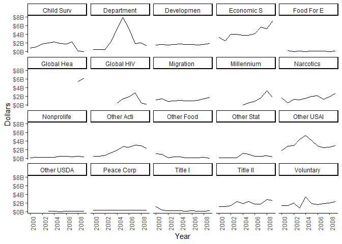

```r
library(scales)
melt00$Year <- as.numeric(str_sub(melt00$Year,3,6))
meltAgg <- aggregate(Dollars~Program.Name+Year,data = melt00,
                     sum,na.rm=T)
meltAgg$Program.Name <- str_sub(meltAgg$Program.Name,1,10)
meltAgg %>%
  ggplot(aes(Year,Dollars))+
  geom_line(aes(group=Program.Name))+
  facet_wrap(~Program.Name)+
  scale_x_continuous(breaks=seq(from=2000, to=2009, by=2))+
  theme(axis.text.x=element_text(angle=90, vjust=1, hjust=0))+
  scale_y_continuous(labels = multiple_format(extra=dollar,multiple="B"))
```

### 14.3.2 dcast

```r
cast00 <- dcast(melt00,Country.Name + Program.Name ~ Year,
                value.var = "Dollars")
head(cast00,3)
  Country.Name                              Program.Name 2000    2001    2002
1  Afghanistan                 Child Survival and Health   NA      NA 2586555
2  Afghanistan Department of Defense Security Assistance   NA      NA 2964313
3  Afghanistan                    Development Assistance   NA 4110478 8762080
      2003      2004      2005      2006      2007      2008      2009
1 56501189  40215304  39817970  40856382  72527069  28397435        NA
2       NA  45635526 151334908 230501318 214505892 495539084 552524990
3 54538965 180539337 193598227 212648440 173134034 150529862   3675202
```

# 15. Reshaping Data+Tidyverse

## 15.1 合并行和列

- bind_rows
- bind_cols

优点：对data.frames(and tibbles)非常好。

缺点：不能用于vectors和matrices

```r
library(dplyr)
library(tibble)

sportLeague <- tibble(sport=c("Hockey", "Baseball", "Football"),
                      league=c("NHL", "MLB", "NFL"))
trophy <- tibble(trophy=c("Stanley Cup", "Commissioner's Trophy",
                          "Vince Lombardi Trophy"))

trophies1 <- bind_cols(sportLeague,trophy)
trophies2 <- tribble(
  ~sport, ~league, ~trophy,
  "Basketball", "NBA", "Larry O'Brien Championship Trophy",
  "Golf", "PGA", "Wanamaker Trophy"
)

trophies <- bind_rows(trophies1,trophies2)

trophies
# A tibble: 5 x 3
  sport      league trophy
  <chr>      <chr>  <chr>
1 Hockey     NHL    Stanley Cup
2 Baseball   MLB    Commissioner's Trophy
3 Football   NFL    Vince Lombardi Trophy
4 Basketball NBA    Larry O'Brien Championship Trophy
5 Golf       PGA    Wanamaker Trophy
```

## 15.2 Joins with dplyr

```r
library(readr)
colorsURL <- 'http://www.jaredlander.com/data/DiamondColors.csv'
diamondColors <- read_csv(colorsURL)
diamondColors
# A tibble: 10 x 3
   Color Description          Details
   <chr> <chr>                <chr>
 1 D     Absolutely Colorless No color
 2 E     Colorless            Minute traces of color
 3 F     Colorless            Minute traces of color
 4 G     Near Colorless       Color is dificult to detect
 5 H     Near Colorless       Color is dificult to detect
 6 I     Near Colorless       Slightly detectable color
 7 J     Near Colorless       Slightly detectable color
 8 K     Faint Color          Noticeable color
 9 L     Faint Color          Noticeable color
10 M     Faint Color          Noticeable color
```

```r
data("diamonds")
unique(diamonds$color)
[1] E I J H F G D
Levels: D < E < F < G < H < I < J
```

```r
library(dplyr)
left_join(diamonds,diamondColors,by=c("color"="Color"))
# A tibble: 53,940 x 12
   carat cut   color clarity depth table price     x     y     z Description
   <dbl> <ord> <chr> <ord>   <dbl> <dbl> <int> <dbl> <dbl> <dbl> <chr>
 1 0.23  Ideal E     SI2      61.5    55   326  3.95  3.98  2.43 Colorless
 2 0.21  Prem~ E     SI1      59.8    61   326  3.89  3.84  2.31 Colorless
 3 0.23  Good  E     VS1      56.9    65   327  4.05  4.07  2.31 Colorless
 4 0.290 Prem~ I     VS2      62.4    58   334  4.2   4.23  2.63 Near Color~
 5 0.31  Good  J     SI2      63.3    58   335  4.34  4.35  2.75 Near Color~
 6 0.24  Very~ J     VVS2     62.8    57   336  3.94  3.96  2.48 Near Color~
 7 0.24  Very~ I     VVS1     62.3    57   336  3.95  3.98  2.47 Near Color~
 8 0.26  Very~ H     SI1      61.9    55   337  4.07  4.11  2.53 Near Color~
 9 0.22  Fair  E     VS2      65.1    61   337  3.87  3.78  2.49 Colorless
10 0.23  Very~ H     VS1      59.4    61   338  4     4.05  2.39 Near Color~
# ... with 53,930 more rows, and 1 more variable: Details <chr>
```

```r
left_join(diamonds,diamondColors,by=c("color"="Color")) %>%
  select(carat,color,price,Description,Details)
# A tibble: 53,940 x 5
   carat color price Description    Details
   <dbl> <chr> <int> <chr>          <chr>
 1 0.23  E       326 Colorless      Minute traces of color
 2 0.21  E       326 Colorless      Minute traces of color
 3 0.23  E       327 Colorless      Minute traces of color
 4 0.290 I       334 Near Colorless Slightly detectable color
 5 0.31  J       335 Near Colorless Slightly detectable color
 6 0.24  J       336 Near Colorless Slightly detectable color
 7 0.24  I       336 Near Colorless Slightly detectable color
 8 0.26  H       337 Near Colorless Color is dificult to detect
 9 0.22  E       337 Colorless      Minute traces of color
10 0.23  H       338 Near Colorless Color is dificult to detect
# ... with 53,930 more rows
```

```r
left_join(diamonds,diamondColors,by=c("color"="Color")) %>%
  distinct(color,Description)
# A tibble: 7 x 2
  color Description
  <chr> <chr>
1 E     Colorless
2 I     Near Colorless
3 J     Near Colorless
4 H     Near Colorless
5 F     Colorless
6 G     Near Colorless
7 D     Absolutely Colorless
```

```r
all.equal(left_join(diamonds,diamondColors,by=c("color"="Color")),
          inner_join(diamonds,diamondColors,by=c("color"="Color")))
[1] TRUE
```

```r
semi_join(diamondColors,diamonds,by=c("Color"="color"))
# A tibble: 7 x 3
  Color Description          Details
  <chr> <chr>                <chr>
1 D     Absolutely Colorless No color
2 E     Colorless            Minute traces of color
3 F     Colorless            Minute traces of color
4 G     Near Colorless       Color is dificult to detect
5 H     Near Colorless       Color is dificult to detect
6 I     Near Colorless       Slightly detectable color
7 J     Near Colorless       Slightly detectable color
```

```r
anti_join(diamondColors, diamonds, by=c('Color'='color'))
# A tibble: 3 x 3
  Color Description Details
  <chr> <chr>       <chr>
1 K     Faint Color Noticeable color
2 L     Faint Color Noticeable color
3 M     Faint Color Noticeable color
```

## 15.3 pivot_longer & pivot_wider

# 16.字符串操作

## 16.1 paste

```r
paste("Hello", "Jared", "and others")
[1] "Hello Jared and others"
```

paste(…, sep = " ", collapse = NULL, recycle0 = FALSE)

可以看出paste有3个参数，sep，collapse

```r
paste("Hello", "Jared", "and others",sep = "/")
[1] "Hello/Jared/and others"
```

像其他函数一样，paste是向量化的。这意味着每一个元素都是一个vector,并被放在一起。

```r
paste(c("Hello", "Hey", "Howdy"), c("Jared", "Bob", "David"))
[1] "Hello Jared" "Hey Bob"     "Howdy David"
```

```r
paste("Hello",c("Jared", "Bob", "David"))
[1] "Hello Jared" "Hello Bob"   "Hello David"
```

```r
vectorOfText <- c("Hello", "Everyone", "out there", ".")
paste(vectorOfText,collapse = " ")
[1] "Hello Everyone out there ."
```

## 16.2 sprintf

```r
person <- "Jared"
partySize <- "eight"
waitTime <- 25

paste("Hello ", person, ", your party of ", partySize,
      " will be seated in ", waitTime, " minutes.", sep="")
[1] "Hello Jared, your party of eight will be seated in 25 minutes."
```

```r
sprintf("Hello %s, your party of %s will be seated in %s minutes",
        person,partySize,waitTime)
[1] "Hello Jared, your party of eight will be seated in 25 minutes"
```

```r
sprintf("Hello %s, your party of %s will be seated in %s minutes",
        c("Jared", "Bob"), c("eight", 16, "four", 10), waitTime)
[1] "Hello Jared, your party of eight will be seated in 25 minutes"
[2] "Hello Bob, your party of 16 will be seated in 25 minutes"
[3] "Hello Jared, your party of four will be seated in 25 minutes"
[4] "Hello Bob, your party of 10 will be seated in 25 minutes"
```

## 16.3 提取文本

核心函数：

- str_split()
- str_sub()
- str_detect(string,pattern)
- str_trim() 去掉text周围的spaces
- str_extract(string,pattern)
- str_replace(string,pattern,replacement)
- str_replace_all()
- `\\d`是`[0-9]`的简写形式
- .+?→出现一次或多次，但不是贪婪匹配

```r
# head(str_extract(theStart,pattern = "^\\d{4}"),30) #提取开头的4个数字
# head(str_extract(theStart,pattern = "\\d{4}$"),30)#提取结尾的4个数字
# head(str_extract(theStart,pattern = "^\\d{4}$"),30)
```

# 17.概率分布

# 17.1 正态分布

最常见的分布类型，正态分布，又叫Gaussian分布。

核心函数：

- rnorm
- dnorm
- pnorm

```r
rnorm(n=10,mean = 100,sd=20) #默认生成mean=0，sd=1的数
 [1]  74.02551  93.44511 108.94800  92.60192 107.19166 118.32264 122.00816
 [8] 114.43929 121.39587  72.40197
```

dnrom: The density(the probability of a particular value) for the normal distribution is usingdnorm. 正态分布特定值的计算,but this is an estimate of the probability.

```r
randNorm10 <- rnorm(10)
dnorm(randNorm10)
 [1] 0.1391240 0.1092420 0.3790524 0.3797643 0.2388485 0.1080022 0.3004694
 [8] 0.2377674 0.3862402 0.3349397
```

```r
dnorm(c(-1,0,1))
[1] 0.2419707 0.3989423 0.2419707
```

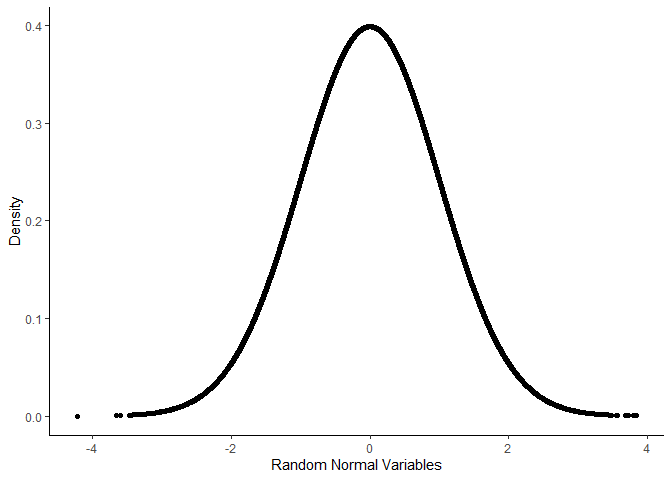

```r
randNorm <- rnorm(30000)
randDensity <- dnorm(randNorm)
library(ggplot2)
ggplot(data.frame(x=randNorm,y=randDensity),aes(x,y))+
  geom_point()+
  labs(x="Random Normal Variables",y="Density")
```

类似的，pnorm()计算的是the cumulative probability that a given number.即累计频率

```r
pnorm(randNorm10)
 [1] 0.92668207 0.05375312 0.37455242 0.37679939 0.84444701 0.94701550
 [7] 0.77426158 0.84551196 0.39959671 0.72286761
```

```r
pnorm(c(-3,0,3))
[1] 0.001349898 0.500000000 0.998650102
```

默认情况下只是left-tailed. 如果想要计算中间的值，则需要差值,即曲线下面积。

```r
pnorm(1)-pnorm(0)
[1] 0.3413447
```

```r
pnorm(1)-pnorm(-1)
[1] 0.6826895
```

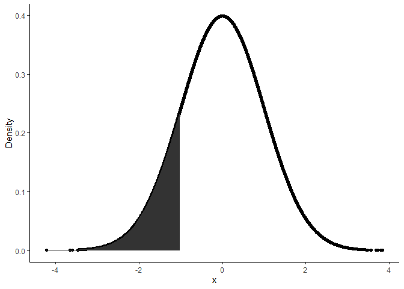

```r
p <- ggplot(data.frame(x=randNorm,y=randDensity),aes(x,y))+
  geom_point()+labs(x="x",y="Density")

neg1Seq <- seq(from=min(randNorm),to=-1,by=.1) #生成最小值到-1之间的数
lessThanNeg1 <- data.frame(x=neg1Seq,y=dnorm(neg1Seq))

lessThanNeg1 <- rbind(c(min(randNorm),0),
                      lessThanNeg1,
                      c(max(lessThanNeg1$x),0)) #加上左侧起点和右侧终点

p+geom_polygon(data = lessThanNeg1,aes(x,y))
```

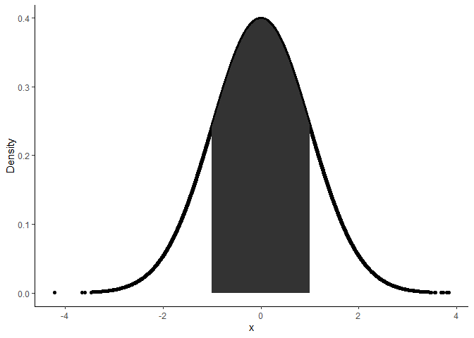

```r
neg1Pos1Seq <- seq(-1,1,by=.1)
neg1To1 <- data.frame(x=neg1Pos1Seq,y=dnorm(neg1Pos1Seq))
neg1To1 <- rbind(c(min(neg1To1),0),
                 neg1To1,
                 c(max(neg1To1),0))
p+geom_polygon(data=neg1To1,aes(x,y))
```

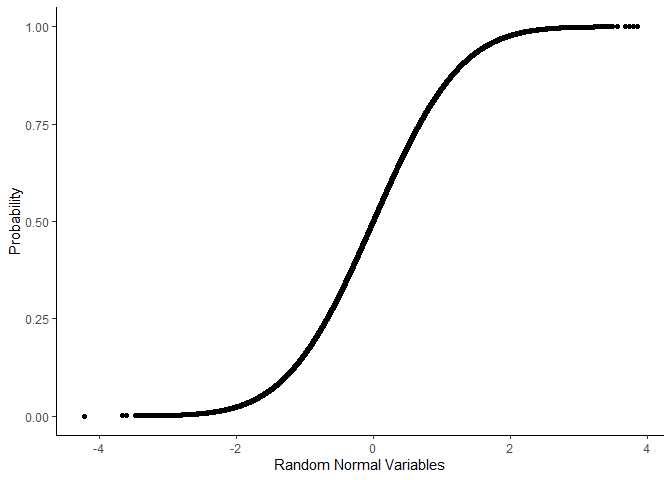

```r
randProb <- pnorm(randNorm)
ggplot(data.frame(x=randNorm,y=randProb),aes(x,y))+
  geom_point()+
  labs(x="Random Normal Variables", y="Probability")
```

The opposite of pnorm is qnorm. Given a cumulative probability it returns the quantile.

```r
head(randNorm10,3)
[1]  1.4515173 -1.6095038 -0.3198199
all.equal(randNorm10,qnorm(pnorm(randNorm10)))
[1] TRUE
```

## 17.2 二项分布

核心函数： rbinom(n,size,prob)

- prob→发生某个事件（success）的概率

```r
rbinom(n=5,size = 10,prob = .4)
[1] 4 3 7 1 1
```

当size=1时，直接从Bernoulli random variable中选取数据，仅有1(success)和0(failure).

```r
rbinom(n=10,size=1,prob = 0.4)
 [1] 1 0 0 1 0 0 0 0 0 0
```

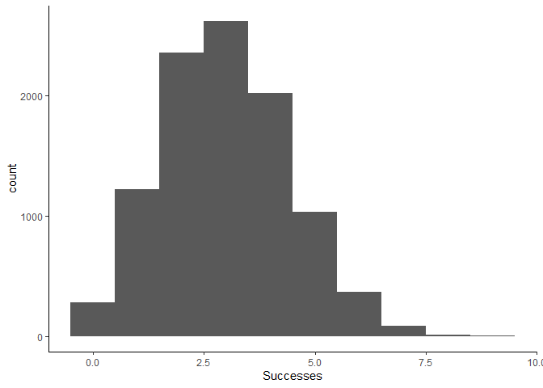

```r
binomData <- data.frame(Successes=rbinom(n=10000,size = 10,prob = .3))
ggplot(binomData,aes(x=Successes))+
  geom_histogram(binwidth = 1)
```

```r
binom5 <- data.frame(Successes=rbinom(n=10000,size = 5,prob = .3),Size=5)
dim(binom5);head(binom5)
[1] 10000     2
  Successes Size
1         1    5
2         0    5
3         1    5
4         2    5
5         2    5
6         1    5
```

```r
binom10 <- data.frame(Successes=rbinom(n=10000, size=10, prob=.3), Size=10)
binom100 <- data.frame(Successes=rbinom(n=10000, size=100, prob=.3), Size=100)
binom1000 <- data.frame(Successes=rbinom(n=10000, size=1000, prob=.3), Size=1000)
binomAll <- rbind(binom5,binom10,binom100,binom1000)
dim(binomAll)
[1] 40000     2
```

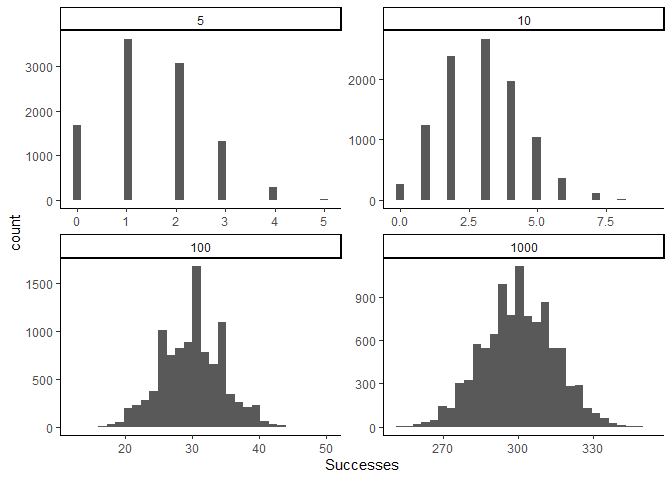

```r
ggplot(binomAll,aes(x=Successes))+
  geom_histogram()+
  facet_wrap(~Size,scales = "free")
```

## 17.3 Poission 分布

```r
pois1 <- rpois(n=10000,lambda = 1)
pois2 <- rpois(n=10000, lambda=2)
pois5 <- rpois(n=10000, lambda=5)
pois10 <- rpois(n=10000, lambda=10)
pois20 <- rpois(n=10000, lambda=20)
pois <- data.frame(Lambda.1=pois1, Lambda.2=pois2,
                   Lambda.5=pois5, Lambda.10=pois10,Lambda.20=pois20)
library(reshape2)
pois <- melt(pois,variable.name = "Lambda",value.name = "x")
pois$Lambda <- as.factor(as.numeric(str_extract(string = pois$Lambda,
                                                pattern = "\\d+")))
head(pois)
  Lambda x
1      1 2
2      1 1
3      1 0
4      1 1
5      1 1
6      1 1
```

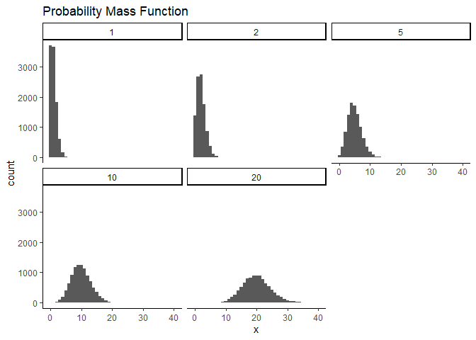

```r
ggplot(pois,aes(x=x))+
  geom_histogram(binwidth = 1)+
  facet_wrap(~Lambda)+
  ggtitle("Probability Mass Function")
```

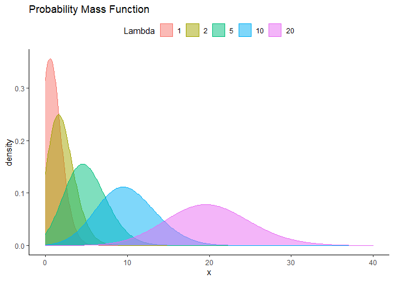

```r
ggplot(pois,aes(x=x))+
  geom_density(aes(group=Lambda,color=Lambda,fill=Lambda),adjust=4,alpha=1/2)+
  scale_color_discrete()+
  scale_fill_discrete()+
  ggtitle("Probability Mass Function")
```